# Explatory Data Analysis on Datasets

Lance Salmingo

23-05-2025

For this project you would need to install the following packages:

```
install.packages("tidyverse")
install.packages("ggplot2")
install.packages("conflicted")
install.packages("lubridate")
install.packages("ggpubr")
```

# Setup

```r
# Load libraries

library(tidyverse)  # For data wrangling
```

```r
library(ggplot2)    # For visualisation
library(conflicted) # For handling library conflicts
library(lubridate)  # For parsing date values
library(ggpubr)     # For stat_cor()
library(readxl)     # For reading excel files

# Load functions to create input files for ORYZA
source("ORYZA_Model_RTOOLS/Make_EXP_ORYZA.R")
source("ORYZA_Model_RTOOLS/Make_WTH_ORYZA.R")

# Prefer dplyr
conflict_prefer("filter",  "dplyr")
```

```
## [conflicted] Will prefer dplyr::filter over any other package.
```

```r
conflict_prefer("select",  "dplyr")
```

```
## [conflicted] Will prefer dplyr::select over any other package.
```

```r
conflict_prefer("lag",     "dplyr")
```

```
## [conflicted] Will prefer dplyr::lag over any other package.
```

```r
conflict_prefer("summarise", "dplyr")
```

```
## [conflicted] Will prefer dplyr::summarise over any other package.
```

```r
# Knitr options
knitr::opts_chunk$set(echo = TRUE, error = TRUE, message = FALSE)
```

# Read datasets

```r
# Read csv files
iot_data <- read_csv("./datasets/IoTProcessed_Data.csv")
res_data <- read_excel("./ORYZA_v3.5/ORYZA Analysis Tool(v4.2).xlsm",
                       sheet = "res", skip = 1)
op_data <- read_excel("./ORYZA_v3.5/ORYZA Analysis Tool(v4.2).xlsm",
                      sheet = "op")

weather_data <- read_csv("./datasets/weather_input.csv")

# Fix column naming
iot_data <- iot_data %>%
  rename(
    temperature = tempreature
  )

iot_data
```

```
## # A tibble: 37,922 × 13
##    date                temperature humidity water_level     N     P     K
##    <dttm>                    <dbl>    <dbl>       <dbl> <dbl> <dbl> <dbl>
##  1 2024-02-08 06:10:00          41       63         100   255   255   255
##  2 2024-02-08 06:15:00          41       59         100   255   255   255
##  3 2024-02-08 06:20:00          41       62         100   255   255   255
##  4 2024-02-08 06:05:00          40       60         100   255   255   255
##  5 2024-02-08 06:00:00          39       61         100   255   255   255
##  6 2024-01-18 06:02:00          38       64         100   255   255   255
##  7 2024-01-18 06:07:00          38       65         100   255   255   255
##  8 2024-01-18 06:12:00          38       64         100   255   255   255
##  9 2024-01-18 05:02:00          37       62         100   255   255   255
## 10 2024-01-18 05:07:00          37       63         100   255   255   255
## # ℹ 37,912 more rows
## # ℹ 6 more variables: Fan_actuator_OFF <dbl>, Fan_actuator_ON <dbl>,
## #   Watering_plant_pump_OFF <dbl>, Watering_plant_pump_ON <dbl>,
## #   Water_pump_actuator_OFF <dbl>, Water_pump_actuator_ON <dbl>
```

# Explore IoT Dataset

```r
# Since ORYZA takes daily values we get group by day and get the mean
# values of each parameter
iot_daily <- iot_data %>%
  # 1) Extract the calendar day from your POSIXct
  mutate(day = as.Date(date)) %>%
  # 2) Group by that day
  group_by(day) %>%
  # 3) Average every numeric column except the original date
  summarise(
    min_temp = min(temperature, na.rm = TRUE),
    max_temp = max(temperature, na.rm = TRUE),
    mean_h = mean(humidity, na.rm = TRUE),
    mean_n = mean(N, na.rm = TRUE),
    mean_p = mean(P, na.rm = TRUE),
    mean_k = mean(K, na.rm = TRUE)
  ) %>%
  ungroup()

# Inspect
print(iot_daily)
```

```
## # A tibble: 102 × 7
##    day        min_temp max_temp mean_h mean_n mean_p mean_k
##    <date>        <dbl>    <dbl>  <dbl>  <dbl>  <dbl>  <dbl>
##  1 2023-11-27       12       29   66.5   185    190    160
##  2 2023-11-28       12       33   66.5   185    190    160
##  3 2023-11-29       11       25   62.0   185    190    160
##  4 2023-11-30       11       26   60.7   185.   190.   161.
##  5 2023-12-01       12       33   59.1   185.   190.   160.
##  6 2023-12-02       14       31   58.5   185    190    160
##  7 2023-12-03       12       35   68.9   185    190    160
##  8 2023-12-04       14       34   72.8   185    190    160
##  9 2023-12-05       15       30   70.8   185.   190.   160
## 10 2023-12-06       14       27   64.7   184.   189.   159.
## # ℹ 92 more rows
```

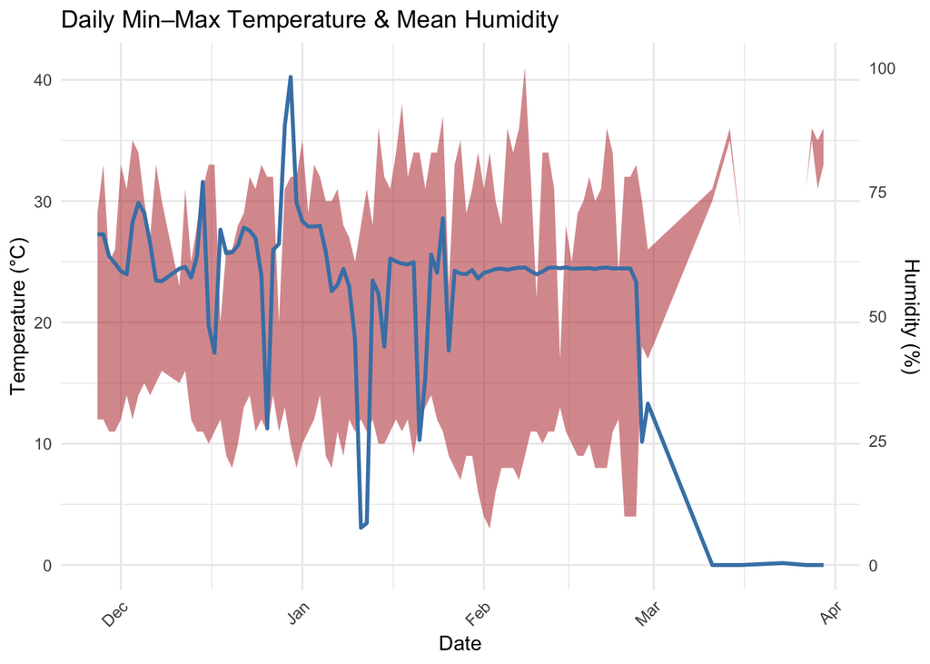

```r
# Plot Temperature and Humidity
ggplot(iot_daily, aes(x = day)) +
  # ribbon for temperature
  geom_ribbon(aes(ymin = min_temp,
                  ymax = max_temp),
              fill  = "firebrick",
              alpha = 0.5) +
  # line for humidity, but we’ll rescale it to sit on the same primary axis
  geom_line(aes(y = mean_h * (max(iot_daily$max_temp)/100)),
            color = "steelblue",
            size  = 1) +

  # primary axis is temperature
  scale_y_continuous(
    name     = "Temperature (°C)",
    # mirror secondary axis by undoing the scale factor
    sec.axis = sec_axis(~ . * (100 / max(iot_daily$max_temp)),
                        name = "Humidity (%)")
  ) +

  labs(
    x     = "Date",
    title = "Daily Min–Max Temperature & Mean Humidity"
  ) +
  theme_minimal() +
  theme(
    axis.text.x     = element_text(angle = 45, hjust = 1),
    legend.position = "none"
  )
```

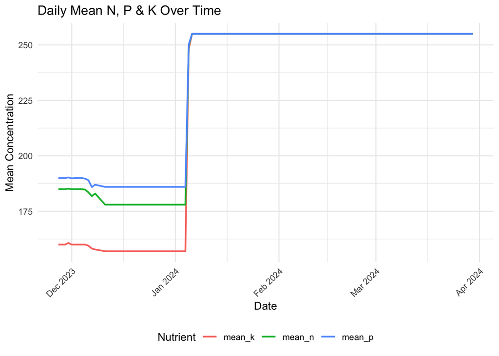

```r
# 1) Pivot to long form
daily_long <- iot_daily %>%
  pivot_longer(
    cols      = c(mean_n, mean_p, mean_k),
    names_to  = "Nutrient",
    values_to = "Concentration"
  )

# 2) Overlayed line plot
ggplot(daily_long, aes(x = day, y = Concentration, color = Nutrient)) +
  geom_line(size = 0.8) +
  scale_x_date(
    date_labels = "%b %Y",    # e.g. "Nov 2023"
    date_breaks = "1 month"
  ) +
  labs(
    title = "Daily Mean N, P & K Over Time",
    x     = "Date",
    y     = "Mean Concentration",
    color = "Nutrient"
  ) +
  theme_minimal() +
  theme(
    axis.text.x     = element_text(angle = 45, hjust = 1),
    legend.position = "bottom"
  )
```

The red ribbon is the minimum and max temperature within the day and the blue line is the humidity.

# Using RTools to create input files

Inspecting the sample of weather and soil data

```r
head(weather_data)
```

```
## # A tibble: 6 × 6
##   DATE        TMAX  TMIN  RAIN  SRAD  RHUM
##   <chr>      <dbl> <dbl> <dbl> <dbl> <dbl>
## 1 01/01/2013  30.9  22.8   0.1  19.6  83.9
## 2 01/02/2013  31.0  21.0   0.8  16.6  74.6
## 3 01/03/2013  32.0  23.9   0    18.6  78.5
## 4 01/04/2013  31.3  23.1  24.6  17.4  81.4
## 5 01/05/2013  33.2  24.1   0    17.9  76.5
## 6 01/06/2013  29.9  23.0   0.5  15.2  85.5
```

From here we can see the daily values for maximum and minimum temperature within the day. As well as rain in mm, solar radiation, and relative humidity.

Solar radiation and rain can be gathered from other IoT sensors but as of the current dataset we have, we can use the dataset to construct the same table to get the max-min temperature and humidity

```r
head(iot_daily)
```

```
## # A tibble: 6 × 7
##   day        min_temp max_temp mean_h mean_n mean_p mean_k
##   <date>        <dbl>    <dbl>  <dbl>  <dbl>  <dbl>  <dbl>
## 1 2023-11-27       12       29   66.5   185    190    160
## 2 2023-11-28       12       33   66.5   185    190    160
## 3 2023-11-29       11       25   62.0   185    190    160
## 4 2023-11-30       11       26   60.7   185.   190.   161.
## 5 2023-12-01       12       33   59.1   185.   190.   160.
## 6 2023-12-02       14       31   58.5   185    190    160
```

```r
iot_input <- iot_daily %>%
  mutate(
    day = format(day, "%m/%d/%Y")
  ) %>%
  rename(
    DATE = day,
    TMAX = max_temp,
    TMIN = min_temp,
    RHUM = mean_h
  )

iot_input
```

```
## # A tibble: 102 × 7
##    DATE        TMIN  TMAX  RHUM mean_n mean_p mean_k
##    <chr>      <dbl> <dbl> <dbl>  <dbl>  <dbl>  <dbl>
##  1 11/27/2023    12    29  66.5   185    190    160
##  2 11/28/2023    12    33  66.5   185    190    160
##  3 11/29/2023    11    25  62.0   185    190    160
##  4 11/30/2023    11    26  60.7   185.   190.   161.
##  5 12/01/2023    12    33  59.1   185.   190.   160.
##  6 12/02/2023    14    31  58.5   185    190    160
##  7 12/03/2023    12    35  68.9   185    190    160
##  8 12/04/2023    14    34  72.8   185    190    160
##  9 12/05/2023    15    30  70.8   185.   190.   160
## 10 12/06/2023    14    27  64.7   184.   189.   159.
## # ℹ 92 more rows
```

Here we can see that from the IoT data we can replicate the needed data to create the input for weather.

For the demonstration we would use the sample data weather_data. Assuming that these were generated from IoT sensors

```r
head(weather_data)
```

```
## # A tibble: 6 × 6
##   DATE        TMAX  TMIN  RAIN  SRAD  RHUM
##   <chr>      <dbl> <dbl> <dbl> <dbl> <dbl>
## 1 01/01/2013  30.9  22.8   0.1  19.6  83.9
## 2 01/02/2013  31.0  21.0   0.8  16.6  74.6
## 3 01/03/2013  32.0  23.9   0    18.6  78.5
## 4 01/04/2013  31.3  23.1  24.6  17.4  81.4
## 5 01/05/2013  33.2  24.1   0    17.9  76.5
## 6 01/06/2013  29.9  23.0   0.5  15.2  85.5
```

```r
make_wth_oryza(weather_data, "./datasets", "LBPH", 5.125, 119.875, 29.96, 1)
```

```r
wth_input <- read_delim("./datasets/WTH/LBPH1.013",
                 delim     = ",",
                 col_names = FALSE)

wth_input
```

```
## # A tibble: 366 × 5
##       X1      X2    X3     X4 X5
##    <dbl>   <dbl> <dbl>  <dbl> <chr>
##  1  120.    5.12  30.0     0  0
##  2    1  2013      1   19635. 22.75,30.85,-99,-99,0.1
##  3    1  2013      2   16600. 21.03,31.03,-99,-99,0.8
##  4    1  2013      3   18584. 23.93,32.03,-99,-99,0
##  5    1  2013      4   17435. 23.12,31.32,-99,-99,24.6
##  6    1  2013      5   17943. 24.1,33.2,-99,-99,0
##  7    1  2013      6   15175. 22.98,29.88,-99,-99,0.5
##  8    1  2013      7   16434. 22.6,30.1,-99,-99,0
##  9    1  2013      8   20673. 22.13,31.63,-99,-99,0
## 10    1  2013      9   13740. 23.43,28.03,-99,-99,0
## # ℹ 356 more rows
```

As seen here the sample weather_data has been converted to the input for the model as wth_input.

This will convert the weather data into a format that ORYZA will take as input.

# Explore res dataset

This dataset contains the daily output of the model during the simulation. TIME = Day number CROPSTA = growth status (1 for sowing, 2 for seed bed, 3 for transplanting, 4 for main field) TMIN = Daily min temperature TMAX = Daily max temperature SON = Total soil organic nitrogen WRR14 = Grain yield 14% of moisture

```r
head(res_data)
```

```
## # A tibble: 6 × 75
##   TIME  DVS   RDD      TMIN  TMAX  LESTRS LRSTRS LDSTRS PCEW  NSP   LAI   GPP
##   <chr> <chr> <chr>    <chr> <chr> <chr>  <chr>  <chr>  <chr> <chr> <chr> <chr>
## 1 1     0     18300000 23.6  30.5  1      1      1      1     0     0     0
## 2 2     0     17300000 23.7  30.2  1      1      1      1     0     0     0
## 3 3     0     13400000 24    30    1      1      1      1     0     0     0
## 4 4     0     22700000 23.6  31.1  1      1      1      1     0     0     0
## 5 5     0     11900000 23.7  30.8  1      1      1      1     0     0     0
## 6 6     0     12100000 23.7  31.1  1      1      1      1     0     0.1   0
## # ℹ 63 more variables: WAGT <chr>, WST <chr>, WLVG <chr>, WLVD <chr>,
## #   WSO <chr>, WRR14 <chr>, WRT <chr>, ZRT <chr>, NSLLV <chr>, RNSTRS <chr>,
## #   NUPP <chr>, ANCR <chr>, ANLV <chr>, ANLD <chr>, ANST <chr>, ANSO <chr>,
## #   ANRT <chr>, TRANSL <chr>, NMAXL <chr>, NMINL <chr>, FNLV <chr>,
## #   ROOTN <chr>, ROOTM <chr>, SNH4 <chr>, SNO3 <chr>, ZW <chr>, IR <chr>,
## #   IRCUM2 <chr>, RAINCUM2 <chr>, RUNOFCUM2 <chr>, EVSW <chr>, EVSWCUM2 <chr>,
## #   TRWCUM2 <chr>, GWTOT <chr>, CAPTOT <chr>, MSKPA1 <chr>, MSKPA2 <chr>, …
```

```r
names(res_data)
```

```
##  [1] "TIME"        "DVS"         "RDD"         "TMIN"        "TMAX"
##  [6] "LESTRS"      "LRSTRS"      "LDSTRS"      "PCEW"        "NSP"
## [11] "LAI"         "GPP"         "WAGT"        "WST"         "WLVG"
## [16] "WLVD"        "WSO"         "WRR14"       "WRT"         "ZRT"
## [21] "NSLLV"       "RNSTRS"      "NUPP"        "ANCR"        "ANLV"
## [26] "ANLD"        "ANST"        "ANSO"        "ANRT"        "TRANSL"
## [31] "NMAXL"       "NMINL"       "FNLV"        "ROOTN"       "ROOTM"
## [36] "SNH4"        "SNO3"        "ZW"          "IR"          "IRCUM2"
## [41] "RAINCUM2"    "RUNOFCUM2"   "EVSW"        "EVSWCUM2"    "TRWCUM2"
## [46] "GWTOT"       "CAPTOT"      "MSKPA1"      "MSKPA2"      "WL0"
## [51] "WCL1"        "WCL2"        "WCL3"        "WCL4"        "WLFLOUT"
## [56] "CO2C"        "CH4C"        "N2ON"        "NH3"         "LEACHEDN"
## [61] "LEACHEDDOC"  "RUNOFFN"     "MINERALIZED" "FERTILIZER"  "SOC"
## [66] "SON"         "YEAR"        "DOY"         "CROPSTA"     "ETD"
## [71] "TRC"         "EVSC"        "RAIN"        "GERMIN"      "TRW"
```

```r
res <- res_data %>%
  mutate(across(everything(), as.numeric))
res
```

```
## # A tibble: 3,793 × 75
##     TIME    DVS     RDD  TMIN  TMAX LESTRS LRSTRS LDSTRS  PCEW   NSP   LAI   GPP
##    <dbl>  <dbl>   <dbl> <dbl> <dbl>  <dbl>  <dbl>  <dbl> <dbl> <dbl> <dbl> <dbl>
##  1     1 0       1.83e7  23.6  30.5      1      1      1     1     0 0      0
##  2     2 0       1.73e7  23.7  30.2      1      1      1     1     0 0      0
##  3     3 0       1.34e7  24    30        1      1      1     1     0 0      0
##  4     4 0       2.27e7  23.6  31.1      1      1      1     1     0 0      0
##  5     5 0       1.19e7  23.7  30.8      1      1      1     1     0 0      0
##  6     6 0       1.21e7  23.7  31.1      1      1      1     1     0 0.1    0
##  7     7 0.0137  2.11e7  23.5  30.2      1      1      1     1     0 0.112  8.94
##  8     8 0.0273  2.18e7  23    30.1      1      1      1     1     0 0.125 20.8
##  9     9 0.0407  2.02e7  23.1  31.4      1      1      1     1     0 0.140 34.0
## 10    10 0.0542  2.14e7  24    31.6      1      1      1     1     0 0.156 48.8
## # ℹ 3,783 more rows
## # ℹ 63 more variables: WAGT <dbl>, WST <dbl>, WLVG <dbl>, WLVD <dbl>,
## #   WSO <dbl>, WRR14 <dbl>, WRT <dbl>, ZRT <dbl>, NSLLV <dbl>, RNSTRS <dbl>,
## #   NUPP <dbl>, ANCR <dbl>, ANLV <dbl>, ANLD <dbl>, ANST <dbl>, ANSO <dbl>,
## #   ANRT <dbl>, TRANSL <dbl>, NMAXL <dbl>, NMINL <dbl>, FNLV <dbl>,
## #   ROOTN <dbl>, ROOTM <dbl>, SNH4 <dbl>, SNO3 <dbl>, ZW <dbl>, IR <dbl>,
## #   IRCUM2 <dbl>, RAINCUM2 <dbl>, RUNOFCUM2 <dbl>, EVSW <dbl>, …
```

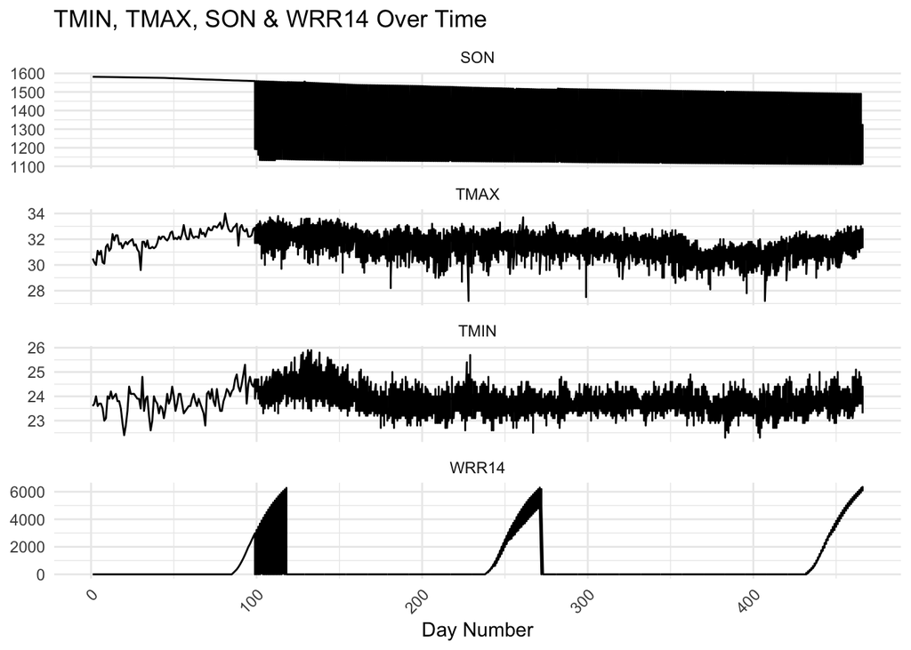

```r
res %>%
  pivot_longer(
    cols      = c(TMIN, TMAX, SON, WRR14),
    names_to  = "Metric",
    values_to = "Value"
  ) %>%
  ggplot(aes(x = TIME, y = Value)) +
    geom_line() +
    facet_wrap(~ Metric, scales = "free_y", ncol = 1) +
    labs(
      x     = "Day Number",
      y     = NULL,
      title = "TMIN, TMAX, SON & WRR14 Over Time"
    ) +
    theme_minimal() +
    theme(axis.text.x = element_text(angle = 45, hjust = 1))
```

# Explore op dataset This dataset contains values that are summarised in the season. Some of the values are: EMD = Julian day of emergence DAE = Days after emergence WRR14 = Grain yield with 14% moisture RAINCUM = Accumulative rainfall in main field IRCUM = Accumulative irrigation in main field SOC = Soil organic carbon content at the end of season SON = Soil organic nitrogen content at the end of season S_CO2C = Total CO2 loss S_N2ON = Total N2O loss

```r
names(op_data)
```

```
##  [1] "RUNNUM"    "ETDCUM"    "EVSCCUM"   "TRCCUM"    "WRR14"     "WSO"
##  [7] "WST"       "WLVG"      "WRT"       "WAGT"      "PARCUM"    "TS"
## [13] "TMAXC"     "TMINC"     "TAVERC"    "DAYSPI"    "DAYSFL1"   "DAYSFL"
## [19] "DAYSFL2"   "SF1"       "SF2"       "SPFERT"    "ANCR"      "RAINCUM"
## [25] "IRCUM"     "RUNOFCUM"  "TRWCUM"    "EVSWCUM"   "DRAICUM"   "CAPTOTCUM"
## [31] "DSWC"      "SOC"       "SON"       "S_CO2C"    "S_CH4C"    "S_N2ON"
## [37] "C_FERN"    "ORGNCUM"   "DEPOSITN"  "EMD"       "DAE"
```

```r
head(op_data)
```

```
## # A tibble: 6 × 41
##   RUNNUM ETDCUM EVSCCUM TRCCUM WRR14   WSO   WST  WLVG   WRT   WAGT PARCUM    TS
##   <chr>   <dbl>   <dbl>  <dbl> <dbl> <dbl> <dbl> <dbl> <dbl>  <dbl>  <dbl> <dbl>
## 1 1        530.    337.   297. 6279. 6414. 3042.  292.  115. 10375    446. 2082.
## 2 2        496     309.   301. 6303  6469. 3089.  301.  108. 10500    398. 2081.
## 3 3        437.    267.   259. 5935. 6111. 3034.  316.  101. 10163    351. 2091.
## 4 4        505.    343.   265. 5649. 5670. 2653.  242.  105.  9090.   344. 2087.
## 5 5        466.    290.   270. 6117. 6291. 3063.  298.  106. 10312    373. 2090.
## 6 6        548.    351.   334. 6188. 6240. 2949.  279.  114. 10082    391. 2092.
## # ℹ 29 more variables: TMAXC <dbl>, TMINC <dbl>, TAVERC <dbl>, DAYSPI <dbl>,
## #   DAYSFL1 <dbl>, DAYSFL <dbl>, DAYSFL2 <dbl>, SF1 <dbl>, SF2 <dbl>,
## #   SPFERT <dbl>, ANCR <dbl>, RAINCUM <dbl>, IRCUM <dbl>, RUNOFCUM <dbl>,
## #   TRWCUM <dbl>, EVSWCUM <dbl>, DRAICUM <dbl>, CAPTOTCUM <dbl>, DSWC <dbl>,
## #   SOC <dbl>, SON <dbl>, S_CO2C <dbl>, S_CH4C <dbl>, S_N2ON <dbl>,
## #   C_FERN <dbl>, ORGNCUM <dbl>, DEPOSITN <dbl>, EMD <dbl>, DAE <dbl>
```

```r
op_data %>%
  select(
    EMD, DAE, WRR14, RAINCUM, IRCUM, SOC, SON, S_CO2C, S_N2ON
  )
```

```
## # A tibble: 22 × 9
##      EMD   DAE WRR14 RAINCUM IRCUM   SOC   SON S_CO2C S_N2ON
##    <dbl> <dbl> <dbl>   <dbl> <dbl> <dbl> <dbl>  <dbl>  <dbl>
##  1     6   112 6279.    112.   550 33732 1553.   333.   0.33
##  2   160   111 6303     315.   400 33275 1514.   289.   0.51
##  3   354   111 5935.    657.    50 33087 1490    153.   0.13
##  4   160   112 5649.    312.   300 32791 1458.   257.   0.59
##  5   354   111 6117.    562.     0 32431 1426.   163.   0.42
##  6   160   112 6188.    316.   500 32052 1392.   221.   0.5
##  7   354   111 6060.    555.    50 31874 1371.   149.   0.31
##  8   160   111 6042.    219.   550 31649 1347    193.   0.41
##  9   354   112 6350.    184.   500 31432 1323    193.   0.49
## 10   160   112 6088.    215.   600 31219 1301.   189.   0.33
## # ℹ 12 more rows
```

The model has much more variables which provide information about the quality of yield and performance of the crop during the season.